# NYShootings

David

2025-01-28

```r
library(tidyverse)
library(dplyr)
library(ggplot2)
```

## NYPD Shootings Data

### Step 1: Importing and Describing Data

Data is sourced from here: https://catalog.data.gov/dataset

The dataset can be found here: https://catalog.data.gov/dataset/nypd-shooting-incident-data-historic

This dataset covers every shooting in NYC from 2006-2023 and includes location, time, and other relevant details surrounding the event.

```r
nypd_shooting_data <- read_csv('https://data.cityofnewyork.us/api/views/833y-fsy8/rows.csv?accessType=DOWNLOAD')
```

### Step 2: Data Summary and Clean Up

In this step we will be removing columns that won’t be used and making data less messy.

```r
nypd_shooting_data <- nypd_shooting_data %>%
  select(-c('INCIDENT_KEY','JURISDICTION_CODE','X_COORD_CD',
            'Y_COORD_CD', Latitude, Longitude, Lon_Lat))
```

Here we change the formatting of the time columns to something more useful.

```r
nypd_shooting_data$OCCUR_DATE <- mdy(nypd_shooting_data$OCCUR_DATE)
nypd_shooting_data$Year <- year(nypd_shooting_data$OCCUR_DATE)
nypd_shooting_data$Hour <- hour(hms(nypd_shooting_data$OCCUR_TIME))
nypd_shooting_data$Weekday <- wday(nypd_shooting_data$OCCUR_DATE, label = TRUE,
                                   abbr = TRUE)
```

In this section we replace bad values from columns with NA. We also re-code the sex columns to prepare for factoring in a later code chunk.

```r
nypd_shooting_data <- nypd_shooting_data %>%

  #changing unknowns in sex columns to 'not stated' for later factoring
  mutate(
    VIC_SEX = recode(VIC_SEX, 'F'='F', 'M'='M', .default = 'Not Stated'),
    PERP_SEX = recode(PERP_SEX, 'F'='F', 'M'='M', .default = 'Not Stated')
        ) %>%

  #replacing unknowns and other bad values with NA
  mutate(across(-c(OCCUR_DATE, Year, PRECINCT, STATISTICAL_MURDER_FLAG,
                   VIC_SEX, PERP_SEX, OCCUR_TIME, Year, Hour, Weekday),
                ~ na_if(.,'(null)'))) %>%
  mutate(across(-c(OCCUR_DATE, Year, PRECINCT, STATISTICAL_MURDER_FLAG,
                   VIC_SEX, PERP_SEX, OCCUR_TIME, Year, Hour, Weekday),
                ~ na_if(.,'UNKNOWN'))) %>%
  mutate(across(-c(OCCUR_DATE,Year,, PRECINCT, STATISTICAL_MURDER_FLAG,
                   VIC_SEX, PERP_SEX, OCCUR_TIME, Year, Hour, Weekday),
                ~ na_if(.,'U')))

#replacing specific bad values that I found with NA
nypd_shooting_data$PERP_AGE_GROUP[nypd_shooting_data$PERP_AGE_GROUP %in% c('1020','1028','224','940')] = NA

nypd_shooting_data$VIC_AGE_GROUP[nypd_shooting_data$VIC_AGE_GROUP %in%
                                   c('1022')] = NA
```

PERP_SEX Column was left with undesirable values. Changing NA values in PERP_SEX to ‘Not Stated’

```r
nypd_shooting_data$PERP_SEX <- nypd_shooting_data$PERP_SEX %>%
#replacing NA in PERP_SEX with 'Not Stated'
   replace_na('Not Stated')
```

We will now factor all applicable columns to allow for easier manipulation when it comes to modeling, analysis, and graphing.

```r
nypd_shooting_data <- nypd_shooting_data %>%
  mutate(across(c(BORO,PRECINCT, PERP_AGE_GROUP, PERP_SEX, PERP_RACE,
                  VIC_AGE_GROUP, VIC_SEX, VIC_RACE,LOC_CLASSFCTN_DESC,
                  LOCATION_DESC, STATISTICAL_MURDER_FLAG, Year, Hour, Weekday), factor))
nypd_shooting_data = droplevels(nypd_shooting_data) #drop unused levels
```

Summary Time!

```r
summary(nypd_shooting_data)
```

```
##    OCCUR_DATE          OCCUR_TIME                  BORO
##  Min.   :2006-01-01   Length:28562      BRONX        : 8376
##  1st Qu.:2009-09-04   Class1:hms        BROOKLYN     :11346
##  Median :2013-09-20   Class2:difftime   MANHATTAN    : 3762
##  Mean   :2014-06-07   Mode  :numeric    QUEENS       : 4271
##  3rd Qu.:2019-09-29                     STATEN ISLAND:  807
##  Max.   :2023-12-29
##
##  LOC_OF_OCCUR_DESC     PRECINCT      LOC_CLASSFCTN_DESC
##  Length:28562       75     : 1628   STREET    : 1886
##  Class :character   73     : 1500   HOUSING   :  460
##  Mode  :character   67     : 1259   DWELLING  :  243
##                     44     : 1076   COMMERCIAL:  208
##                     79     : 1045   OTHER     :   59
##                     47     : 1006   (Other)   :  108
##                     (Other):21048   NA's      :25598
##                    LOCATION_DESC   STATISTICAL_MURDER_FLAG PERP_AGE_GROUP
##  MULTI DWELL - PUBLIC HOUS: 5007   FALSE:23036             <18  : 1682
##  MULTI DWELL - APT BUILD  : 2964   TRUE : 5526             18-24: 6438
##  PVT HOUSE                :  983                           25-44: 6041
##  GROCERY/BODEGA           :  750                           45-64:  699
##  BAR/NIGHT CLUB           :  668                           65+  :   65
##  (Other)                  : 1502                           NA's :13637
##  NA's                     :16688
##        PERP_SEX                              PERP_RACE     VIC_AGE_GROUP
##  F         :  444   AMERICAN INDIAN/ALASKAN NATIVE:    2   <18  : 2954
##  M         :16168   ASIAN / PACIFIC ISLANDER      :  169   18-24:10384
##  Not Stated:11950   BLACK                         :11903   25-44:12973
##                     BLACK HISPANIC                : 1392   45-64: 1981
##                     WHITE                         :  298   65+  :  205
##                     WHITE HISPANIC                : 2510   NA's :   65
##                     NA's                          :12288
##        VIC_SEX                                VIC_RACE          Year
##  F         : 2760   AMERICAN INDIAN/ALASKAN NATIVE:   11   2006   : 2055
##  M         :25790   ASIAN / PACIFIC ISLANDER      :  440   2021   : 2011
##  Not Stated:   12   BLACK                         :20235   2008   : 1959
##                     BLACK HISPANIC                : 2795   2020   : 1948
##                     WHITE                         :  728   2011   : 1939
##                     WHITE HISPANIC                : 4283   2010   : 1912
##                     NA's                          :   70   (Other):16738
##       Hour       Weekday
##  23     : 2397   Sun:5669
##  0      : 2267   Mon:4062
##  22     : 2264   Tue:3331
##  1      : 2142   Wed:3145
##  21     : 2074   Thu:3169
##  2      : 1878   Fri:3759
##  (Other):15540   Sat:5427
```

## Step 3: Data Analysis and Visualization

We will make rough barplots for a large portion of the columns. These will be messy but that is okay cause we’re just trying to get a glimpse at any apparent trends or data that could be interesting to explore.

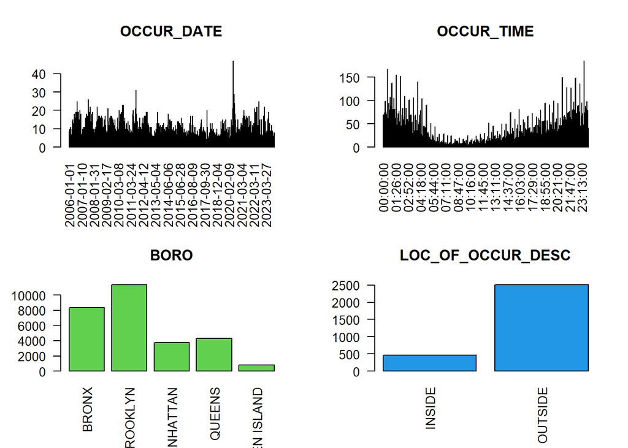

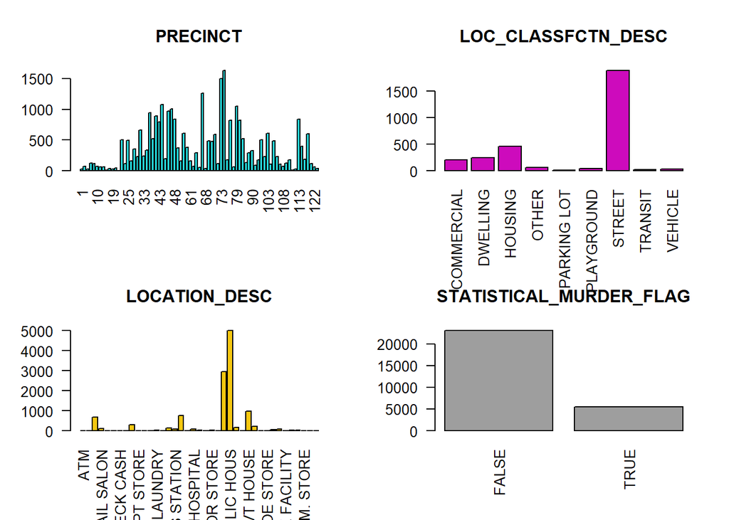

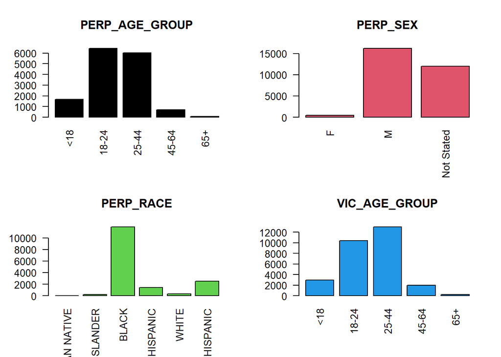

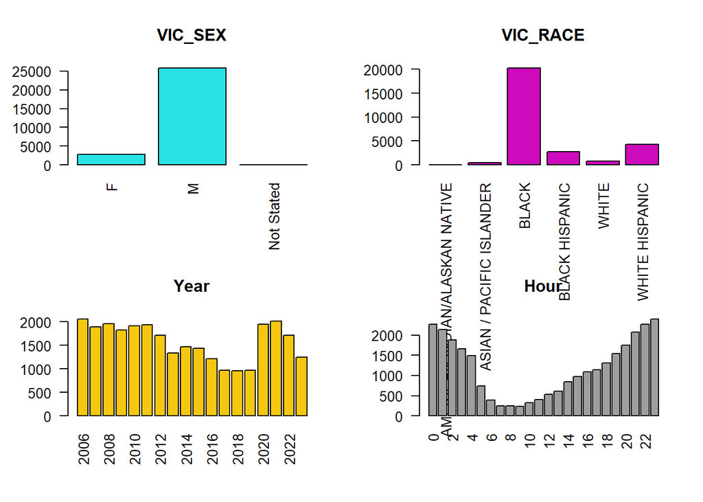

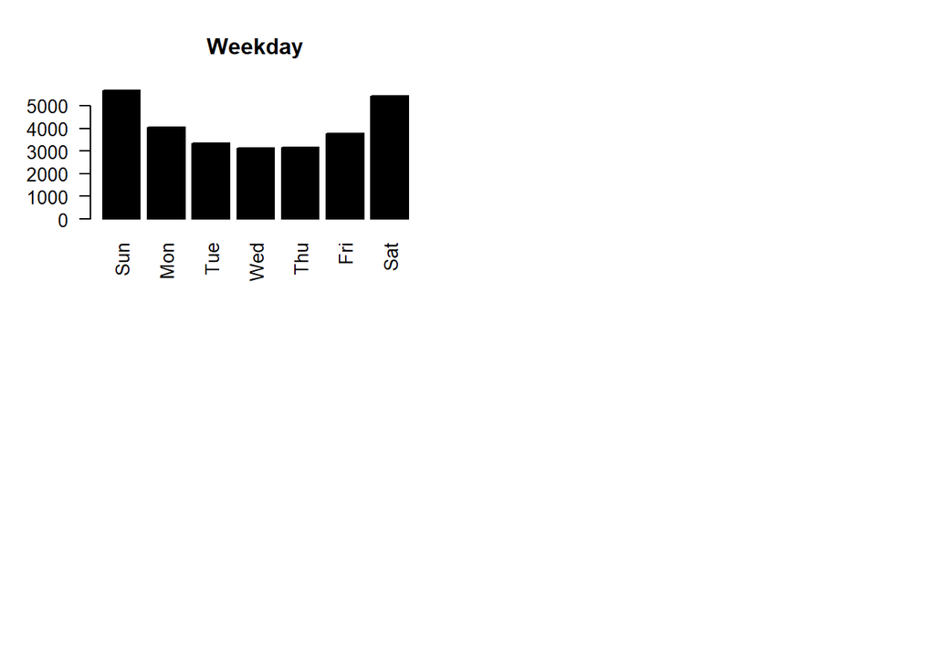

```r
#just getting a look at the data (graphs are messy but that's okay)
par(mfrow = c(2,2))
for (i in 1:17){
      barplot(table(nypd_shooting_data[i]), col = i, las = 2, main = colnames(nypd_shooting_data)[i])
}
```

From the previous graphs the columns that stuck out to me were the temporal data (occur date/time and year)

```r
#looking at percentage of incidents in precincts
nypd_shooting_data <- nypd_shooting_data %>%
  add_count(BORO, PRECINCT, name = 'IncCount') %>%
  add_count(Weekday, Hour, name ='IncCountHours') %>%
  add_count(Year, name = 'ShootingsPerYear')

incidentsPrec <- distinct(nypd_shooting_data, PRECINCT,.keep_all = TRUE)
incidentsPrec <- incidentsPrec %>%
  mutate(
    percentage= ((IncCount)/nrow(nypd_shooting_data) *100)) %>%
  select(c(BORO ,PRECINCT, IncCount, percentage))
#isolating top 10 highest inccount precincts
top10precincts <- head(incidentsPrec[order(-incidentsPrec$IncCount),],n=10)
top10precincts
```

```
## # A tibble: 10 × 4
##    BORO     PRECINCT IncCount percentage
##    <fct>    <fct>       <int>      <dbl>
##  1 BROOKLYN 75           1628       5.70
##  2 BROOKLYN 73           1500       5.25
##  3 BROOKLYN 67           1259       4.41
##  4 BRONX    44           1076       3.77
##  5 BROOKLYN 79           1045       3.66
##  6 BRONX    47           1006       3.52
##  7 BRONX    46            972       3.40
##  8 BRONX    40            947       3.32
##  9 BRONX    42            890       3.12
## 10 BRONX    48            841       2.94
```

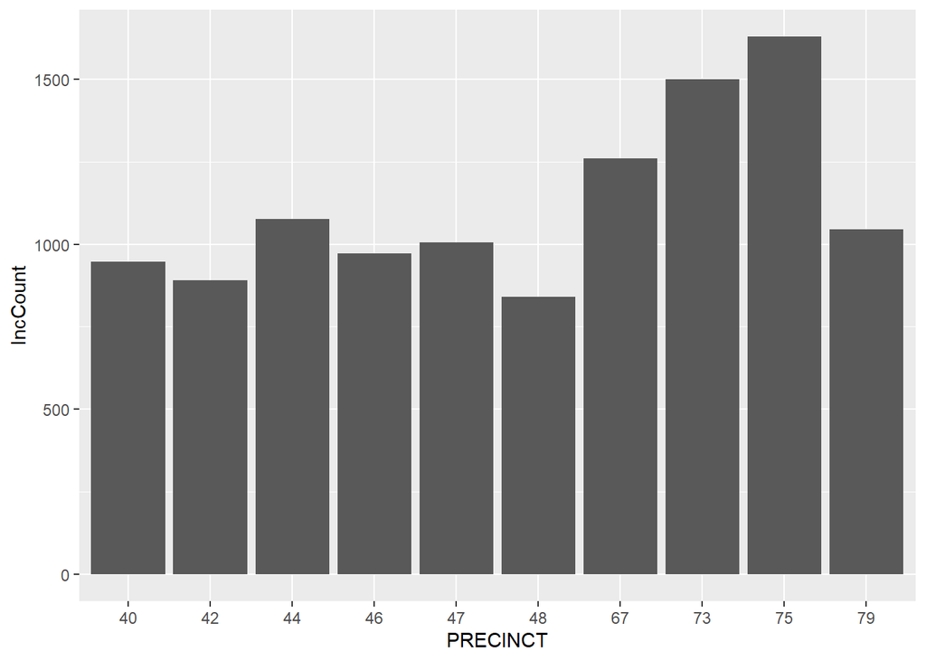

```r
#plot of highest incident precincts
PrecinctPlot <- ggplot(top10precincts,aes(PRECINCT,IncCount)) + geom_col()
print(PrecinctPlot)
```

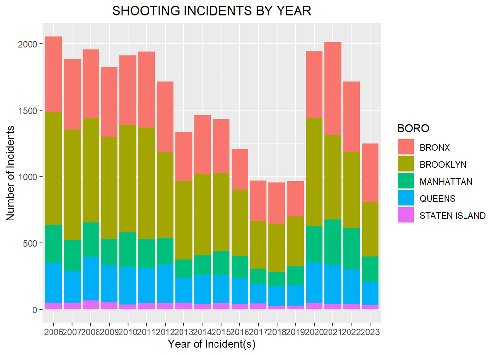

```r
#Incidents per Year by Borough


IncidentsPerYearByBurrough <- ggplot(nypd_shooting_data, aes(Year, fill = BORO)) +
  geom_bar() +
  ggtitle('SHOOTING INCIDENTS BY YEAR') +
  ylab('Number of Incidents') +
  xlab('Year of Incident(s)') +
  theme(plot.title = element_text(hjust = 0.5))
print(IncidentsPerYearByBurrough)
```

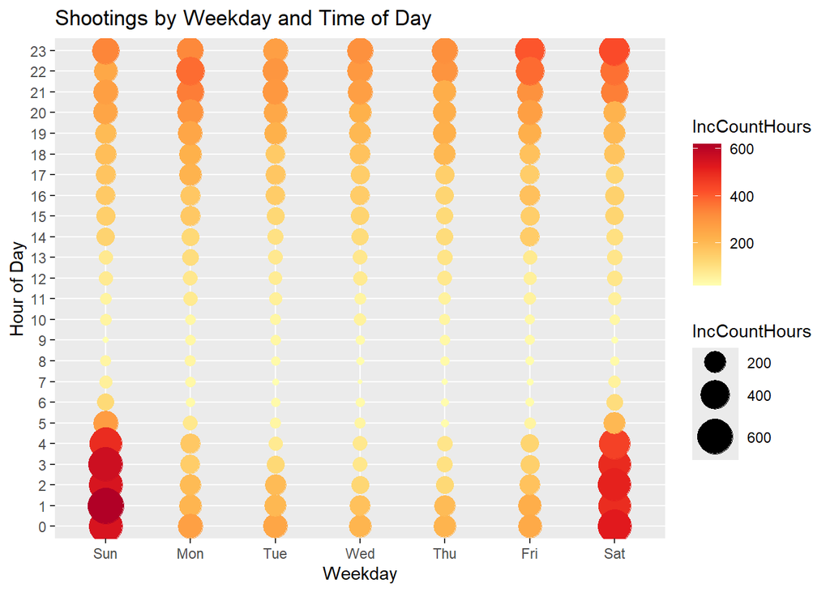

```r
#graphing hour and day of week with incident quantity
#labels and check what days are what with weekday

IncidentsByDayHour <- ggplot(data = nypd_shooting_data, mapping =
                               aes(x = Weekday, y = Hour, size = IncCountHours, colour = IncCountHours) ) + scale_size(range = c(1,10)) + geom_point() + scale_color_distiller(palette = "YlOrRd", direction = 1) +
  ylab("Hour of Day") +
  ggtitle('Shootings by Weekday and Time of Day')
print(IncidentsByDayHour)
```

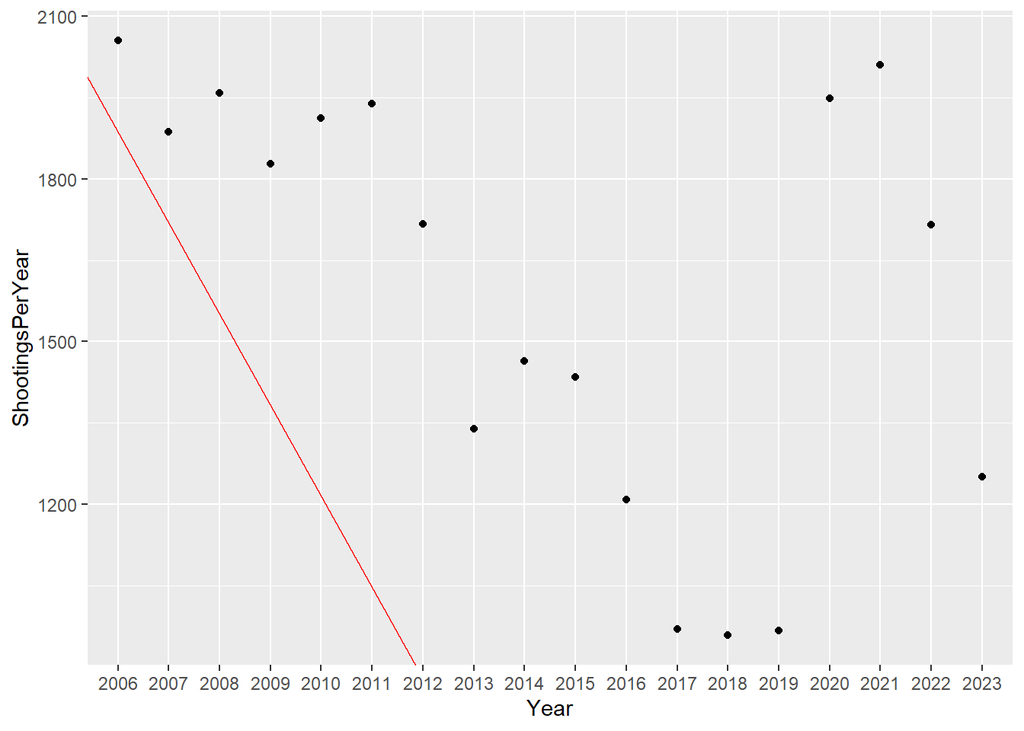

```r
#creating a linear regression line
m <- lm(ShootingsPerYear ~ Year, data = nypd_shooting_data)

#adding the line to the plot
LinReg <- ggplot(nypd_shooting_data, aes(Year, ShootingsPerYear)) + geom_point() +
  geom_abline(aes(intercept = coef(m)[1], slope = coef(m)[2]), colour = "red")
print(LinReg)
```

```r
#as you can see in this graph; this trend is not linear. However, if you were to separate the data into two graphs from 2006 -2019 and 2020 - Present you would see a linear trend in both. There was a massive spike in shootings in 2020 likely due to unrest during the COVID-19 Pandemic.

#not enough data post 2020 so we're just gonna look before 2020
#pre 2020
pre2020 <- filter(nypd_shooting_data, Year == c(2006,2007,2008,2009,2010,2011,
                                                2012,2013,2014,2015,2016,2017,
                                                2018,2019))
m2 <- lm(ShootingsPerYear ~ Year, data = pre2020)
coef(m2)
```

```
## (Intercept)    Year2007    Year2008    Year2009    Year2010    Year2011
##        2055        -168         -96        -227        -143        -116
##    Year2012    Year2013    Year2014    Year2015    Year2016    Year2017
##        -338        -716        -591        -621        -847       -1085
##    Year2018    Year2019
##       -1097       -1088
```

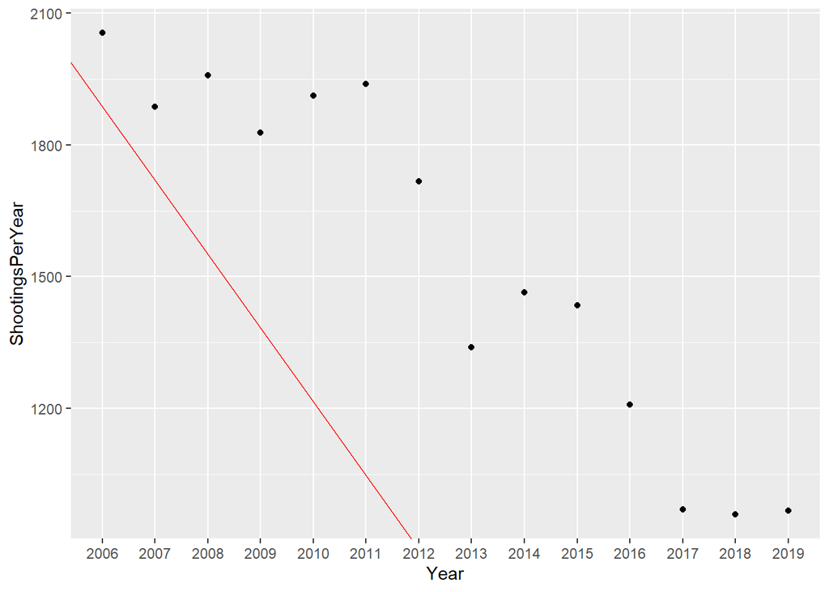

```r
LinRegPre2020 <- ggplot(pre2020, aes(Year, ShootingsPerYear)) + geom_point() +
  geom_abline(aes(intercept = coef(m2)[1], slope = coef(m2)[2]), colour = "red")
print(LinRegPre2020)
```

### Step 4: Conclusion and Bias Sources

From the data we find that the Bronx and Brooklyn, together, have all of the top 10 highest incident count precincts. This is further shown in the Shooting Incidents By Year graph. This graph also shows an interesting trend where shooting incidents rocket back up in 2020 after continually declining since the mid 2000s. This trend is explored with a linear regression model. Sources of bias in this analysis come include the data collectors (NYPD). Is it possible that Manhattan, Queens, and Staten Island have less police on staff therefore lowering shooting incidents reported? This is just one of many questions that could be raised surrounding the bias of this data.